# WCSS 2019: Exploring Twitter Trolls

Benjamin Ortiz Ulloa

2/4/2019

# Explore Twitter Retweet Network

```r
library(magrittr)
```

```r
#load data
tweets <- readr::read_csv('../../igraph-data-days-texas-2019/russian-troll-tweets/tweets.csv')

names(tweets)
```

```
##  [1] "user_id"               "user_key"
##  [3] "created_at"            "created_str"
##  [5] "retweet_count"         "retweeted"
##  [7] "favorite_count"        "text"
##  [9] "tweet_id"              "source"
## [11] "hashtags"              "expanded_urls"
## [13] "posted"                "mentions"
## [15] "retweeted_status_id"   "in_reply_to_status_id"
```

To create a retweeting network, we only need two columns from this data set - **user_key** and **text**. We can isolate these two columns with `dplyr::select`:

```r
retweet_network <- tweets  %>%
  dplyr::select(user_key, text) %>%
  dplyr::mutate(text = stringr::str_replace_all(text, "\\r|\\n", '') ) #clean text of newlines



retweet_network %>%
  head() %>%
  knitr::kable()
```

| user_key | text |
| --- | --- |
| ryanmaxwell_1 | #IslamKills Are you trying to say that there were no terrorist attacks in Europe before refugees were let in? |
| detroitdailynew | Clinton: Trump should’ve apologized more, attacked less https://t.co/eJampkoHFZ |
| cookncooks | RT @ltapoll: Who was/is the best president of the past 25 years? (Vote & Retweet) |
| queenofthewo | RT @jww372: I don’t have to guess your religion! #ChristmasAftermath |
| mrclydepratt | RT @Shareblue: Pence and his lawyers decided which of his official emails the public could seehttps://t.co/HjhPguBK1Y by @alisonrose711 |
| giselleevns | @ModicaGiunta me, too! |

Tweets that are actually retweets begin with **RT**. Because we only care about tweets that were retweeted, we can use `dplyr::filter` to only include instances of retweets. `stringr::str_detect` returns a boolean (*TRUE*/*FALSE*) for text that includes a string we are looking for.

```r
retweet_network <- retweet_network %>%
  dplyr::filter(stringr::str_detect(text, '^RT\\s'))

retweet_network %>%
  head() %>%
  knitr::kable()
```

| user_key | text |
| --- | --- |
| cookncooks | RT @ltapoll: Who was/is the best president of the past 25 years? (Vote & Retweet) |
| queenofthewo | RT @jww372: I don’t have to guess your religion! #ChristmasAftermath |
| mrclydepratt | RT @Shareblue: Pence and his lawyers decided which of his official emails the public could seehttps://t.co/HjhPguBK1Y by @alisonrose711 |
| baobaeham | RT @MDBlanchfield: You’ll never guess who tweeted something false that he saw on TV - The Washington Post https://t.co/K2e4XdXRfu |
| judelambertusa | RT @100PercFEDUP: New post: WATCH: DIAMOND AND SILK Rip On John Kerry Over Israel Comments (VIDEO) https://t.co/NkdKaQ9yYu |
| ameliebaldwin | RT @AriaWilsonGOP: 3 Women Face Charges After Being Caught Stealing Dozens Of Trump Signs https://t.co/JjlZxaW3JN https://t.co/qW2Ok9ROxH |

There is a clear pattern in the text. The character string *RT* is always followed by the twitter handle that is being retweeted. We can use `stringr::str_extract` to pull the twitter handles and `dplyr::mutate` to create a new column with this extracted information.

The code below includes `(?<=@)[^:]+(?=:)`. This is a regex string. Click this link to learn more about regex. The other functions are used for cleaning and formatting purposes.

```r
retweet_network <- retweet_network %>%
  dplyr::mutate(retweeted_account = stringr::str_extract(text, '(?<=@)[^:]+(?=:)') %>%
                  stringr::str_to_lower()) %>% #standardize twitter handles to lower case
  dplyr::filter(!is.na(retweeted_account)) %>% #remove text that starts with "RT" but aren't actually retweets
  dplyr::select(user_key, retweeted_account, text) %>% #reorder columns
  dplyr::distinct()

retweet_network %>%
  head() %>%
  knitr::kable()
```

| user_key | retweeted_account | text |
| --- | --- | --- |
| cookncooks | ltapoll | RT @ltapoll: Who was/is the best president of the past 25 years? (Vote & Retweet) |
| queenofthewo | jww372 | RT @jww372: I don’t have to guess your religion! #ChristmasAftermath |
| mrclydepratt | shareblue | RT @Shareblue: Pence and his lawyers decided which of his official emails the public could seehttps://t.co/HjhPguBK1Y by @alisonrose711 |
| baobaeham | mdblanchfield | RT @MDBlanchfield: You’ll never guess who tweeted something false that he saw on TV - The Washington Post https://t.co/K2e4XdXRfu |
| judelambertusa | 100percfedup | RT @100PercFEDUP: New post: WATCH: DIAMOND AND SILK Rip On John Kerry Over Israel Comments (VIDEO) https://t.co/NkdKaQ9yYu |
| ameliebaldwin | ariawilsongop | RT @AriaWilsonGOP: 3 Women Face Charges After Being Caught Stealing Dozens Of Trump Signs https://t.co/JjlZxaW3JN https://t.co/qW2Ok9ROxH |

We don’t necessarily care about the individual tweets. What we really care about is who a troll retweeted and how often. We can use `dplyr::count` to aggregate the total number of instances a particular `user_key` retweeted another acount

```r
retweet_network_wt <- retweet_network %>%
  dplyr::count(user_key, retweeted_account, sort = T)

retweet_network_wt %>%
  head() %>%
  knitr::kable()
```

| user_key | retweeted_account | n |
| --- | --- | --- |
| paulinett | blicqer | 1049 |
| melanymelanin | blicqer | 798 |
| paulinett | zaibatsunews | 222 |
| giselleevns | chrixmorgan | 218 |
| brianaregland | feministajones | 200 |
| hyddrox | cmdorsey | 178 |

This is a data frame with 81862. This data frame represents an edge list and so we may have too many edges to get a good understanding of our data. We can filter the edges down by choosing a cutoff for the edges. That is, if we assume that a troll retweeting an account less than 5 times is insignificant for our analysis, then we can remove them and clean up our graph.

```r
filter_n <- 5

retweet_network_wt <- retweet_network_wt  %>%
  dplyr::filter(n >= filter_n)

retweet_network_wt %>%
  head() %>%
  knitr::kable()
```

| user_key | retweeted_account | n |
| --- | --- | --- |
| paulinett | blicqer | 1049 |
| melanymelanin | blicqer | 798 |
| paulinett | zaibatsunews | 222 |
| giselleevns | chrixmorgan | 218 |
| brianaregland | feministajones | 200 |
| hyddrox | cmdorsey | 178 |

Cool, now we have only 3675 edges in our graph. Let’s now convert the edge list data frame into an actual **igraph** graph. We can do this using `igraph::graph_from_data_frame`

```r
g_rtwt <- igraph::graph_from_data_frame(retweet_network_wt)

summary(g_rtwt)
```

```
## IGRAPH 2817a9b DN-- 1555 3675 --
## + attr: name (v/c), n (e/n)
```

The **D** at the top of the summary stands for **Directed Graph**, that is, direction matters for the edges. The **N** stands for **Named Graph**, that is, each node has a unque name. We can add metadata to the graph directly with `$` notation - similar to how we would in a list. Any valid name for a list or data frame will be a valid name for a graph attribute. The number of nodes (1555) and the number of edges (3675) follows the graph’s metadata. We are also given a list of edge attributes (**e/c(haracter)**, **e/n(numeric)**, **e/l(ogical)**) and vertex attributes (**v/…**).

```r
g_rtwt$name <- '2016 Russian Twitter Troll Retweet Network'
g_rtwt$info <- "A graph inspired by NBC's and Neo4j's exploration."

summary(g_rtwt)
```

```
## IGRAPH 2817a9b DN-- 1555 3675 -- 2016 Russian Twitter Troll Retweet Networ
## + attr: name (g/c), info (g/c), name (v/c), n (e/n)
```

The name attribute is a special attribute for a graph and is shown in the summary. We can use `$` notation to retrieve other graph attributes.

```r
g_rtwt$info
```

```
## [1] "A graph inspired by NBC's and Neo4j's exploration."
```

If we want to plot a graph, then we simply need to use the `plot` function. For **igraph** graphs, plot takes special parameters to manipulate the vertices and edges on the plot. We will not go into depth about plotting graphs, but if you want to learn more, then please visit Katya Ognyanova’s detail tutorials on graph visualization.. You can also use `?igraph.plotting` to learn more.

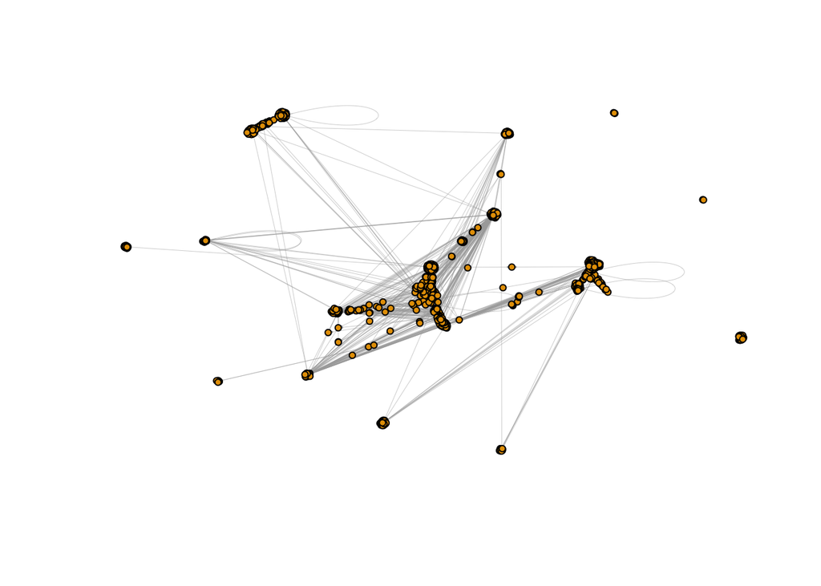

```r
set.seed(4321)
plot(
  g_rtwt,
  vertex.size = 2,
  vertex.label = '',
  edge.arrow.size = .05,
  edge.width = .25,
  asp = 0 #aspect ratio
)
```

**igraph** can readily calculate many different centrality measurements such as `igraph::betweenness`, `igraph::degree`, and `igraph::eigen_centrality`. We will focus on `igraph::page_rank`. These functions return scores at the node level and the order of the scores correspond with the order of the vertices.

```r
pr <- igraph::page_rank(g_rtwt)$vector
head(pr)
```

```
##     paulinett melanymelanin   giselleevns brianaregland       hyddrox
##  0.0005891945  0.0005891945  0.0007005381  0.0005891945  0.0005891945
##    tpartynews
##  0.0018363397
```

```r
head(igraph::V(g_rtwt)$name)
```

```
## [1] "paulinett"     "melanymelanin" "giselleevns"   "brianaregland"
## [5] "hyddrox"       "tpartynews"
```

Because these measurements have the same order of the vertices, we can store the measurements as a vertex attribute.

```r
igraph::V(g_rtwt)$PageRank <- pr
igraph::V(g_rtwt)[[1:6]]
```

```
## + 6/1555 vertices, named, from 2817a9b:
##            name     PageRank
## 1     paulinett 0.0005891945
## 2 melanymelanin 0.0005891945
## 3   giselleevns 0.0007005381
## 4 brianaregland 0.0005891945
## 5       hyddrox 0.0005891945
## 6    tpartynews 0.0018363397
```

If we want to match the vertex information with outside information, the easiest way we can do that is convert the vertex list into a data frame with `igraph::as_data_frame` and then join it with the new data with `dplyr::?_join`. Let’s combine the vertex list with a troll’s total number of tweets.

```r
vertex_df <- igraph::as_data_frame(g_rtwt, 'vertices') %>%
  dplyr::arrange(desc(PageRank))

edges_df <- igraph::as_data_frame(g_rtwt, 'edges')

total_tweets <- tweets %>%
  dplyr::select(user_key, text) %>%
  dplyr::count(user_key) %>%
  dplyr::rename(TotalTweets = n)

vertex_df <- dplyr::left_join(vertex_df, total_tweets, by = c('name' = 'user_key'))

vertex_df %>%
  head() %>%
  knitr::kable()
```

| name | PageRank | TotalTweets |
| --- | --- | --- |
| rt_com | 0.0050983 | NA |
| blacktolive | 0.0039910 | 238 |
| gloed_up | 0.0038694 | 327 |
| chiefplan1 | 0.0038029 | NA |
| rt_america | 0.0035941 | NA |
| ten_gop | 0.0029589 | 3194 |

If the **TotalTweets** of a node is `NA`, then the account is not listed in the list of trolls. This means the twitter trolls are retweeting tweets from real accounts. Let’s recreate the network and use the **TotalTweets** vertex attribute as something to filter out. We can actuaally remove vertices from a graph with `-`.

```r
g_rtwt <- igraph::graph_from_data_frame(edges_df, T, vertex_df) %>%
  {. - igraph::V(.)[is.na(TotalTweets)]} %>%
  {. - igraph::V(.)[igraph::degree(.) == 0]} #remove unconnected nodes

summary(g_rtwt)
```

```
## IGRAPH 1df123b DN-- 83 153 --
## + attr: name (v/c), PageRank (v/n), TotalTweets (v/n), n (e/n)
```

Let’s re-plot the graph.

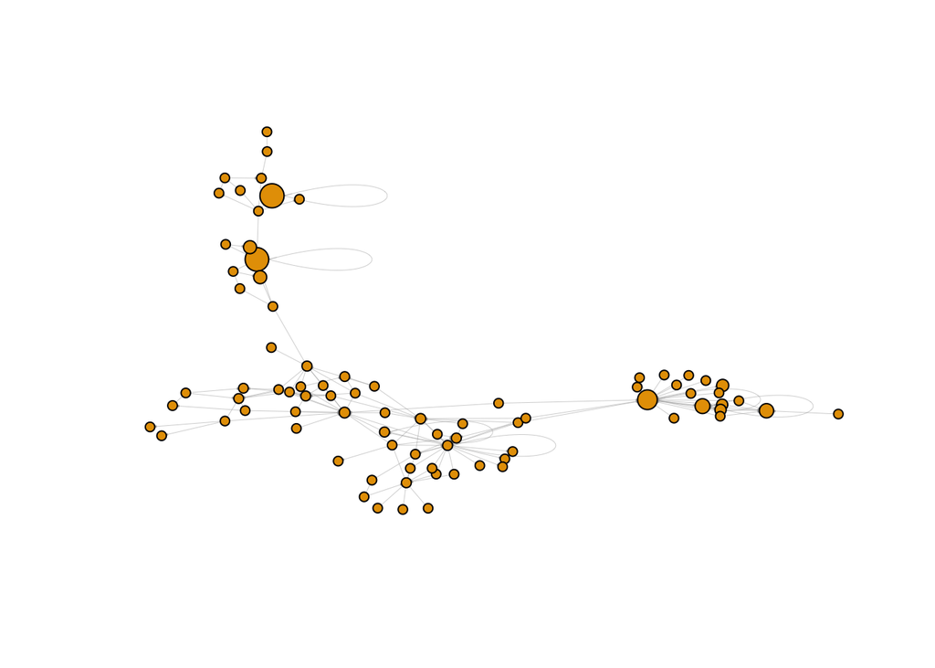

```r
set.seed(4321)
g_rtwt %>%
  plot(
    vertex.size = igraph::V(.)$PageRank/max(igraph::V(.)$PageRank) * 5 + 2,
    vertex.label = '',
    edge.arrow.size = .05,
    edge.width = .25,
    asp = 0 #aspect ratio
  )
```

**igraph** has a number of community detection alogrithms to use including `igraph::informap.community`, `igraph::spinglass.community`, and `igraph::fastgreedy.community`. Here, we will use `igraph::walktrap.community`.

```r
g_community <- igraph::walktrap.community(graph = g_rtwt)
names(g_community)
```

```
## [1] "merges"     "modularity" "membership" "names"      "vcount"
## [6] "algorithm"
```

The the community membership is listed in the same order as the vertices. This means we can store the membership as a vertex attribute. The communities are repesented as numbers. This particular graph has `max(g_community$membership)` communities. We can create a color palette for these communities.

```r
igraph::V(g_rtwt)$community <- g_community$membership

community_pal <- scales::brewer_pal('qual')(max(igraph::V(g_rtwt)$community))
names(community_pal) <- 1:max(igraph::V(g_rtwt)$community)

community_pal
```

```
##         1         2         3         4         5
## "#7FC97F" "#BEAED4" "#FDC086" "#FFFF99" "#386CB0"
```

**color** is a special vertex attribute. If it exists, then the color stored in the vertex is automatically plotted. Let’s iterate over the vertice and assign a color according to it’s community

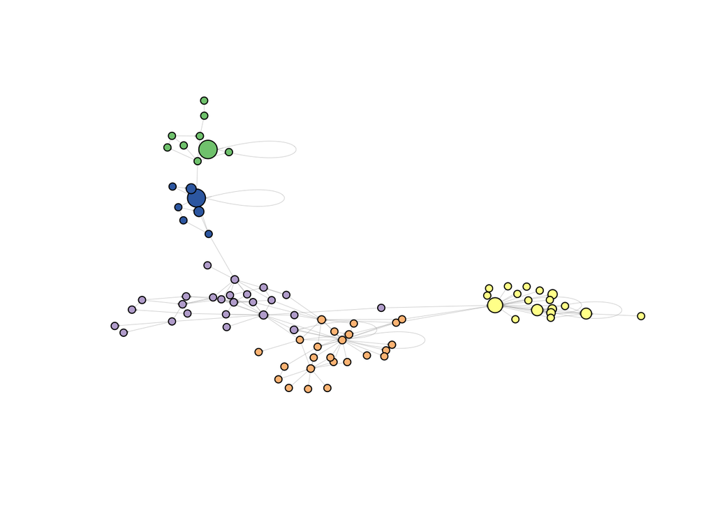

```r
igraph::V(g_rtwt)$color <- purrr::map_chr(igraph::V(g_rtwt)$community, function(x){
  community_pal[[x]]
})

set.seed(4321)
g_rtwt %>%
  plot(
      vertex.size = igraph::V(.)$PageRank/max(igraph::V(.)$PageRank) * 5 + 2,
      vertex.label = '',
      edge.arrow.size = .05,
      edge.width = .25,
      asp = 0 #aspect ratio
  )
```

Let’s take a moment to actually analyze the hashtags associated with these users. We can go back to our original dataset and try to match users with hashtags.

```r
tweet_hashtag <- tweets %>%
  dplyr::select(user_key, hashtags, text) %>%
  dplyr::distinct()%>%
  dplyr::filter(hashtags != '[]') %>% #this represents a tweet with no hashtags
  dplyr::mutate(hashtags = purrr::map(hashtags, jsonlite::fromJSON)) %>% #the stored info is a json file
  tidyr::unnest()  %>%
  dplyr::select(user_key, hashtags)
```

Join the hashtag data with the vertex data, then aggregate

```r
vertex_df <- igraph::as_data_frame(g_rtwt, 'vertices')
edge_df <- igraph::as_data_frame(g_rtwt, 'edges')

community_hashtags <- vertex_df %>%
  dplyr::left_join(tweet_hashtag, by = c('name' = 'user_key')) %>%
  dplyr::count(community, hashtags, sort = T)  %>%
  dplyr::group_by(community) %>%
  dplyr::top_n(6, wt = n) %>%
  dplyr::ungroup()

community_hashtags %>%
  head() %>%
  knitr::kable()
```

| community | hashtags | n |
| --- | --- | --- |
| 4 | maga | 1598 |
| 4 | Trump | 1038 |
| 4 | tcot | 877 |
| 2 | news | 854 |
| 4 | NeverHillary | 747 |
| 3 | RejectedDebateTopics | 570 |

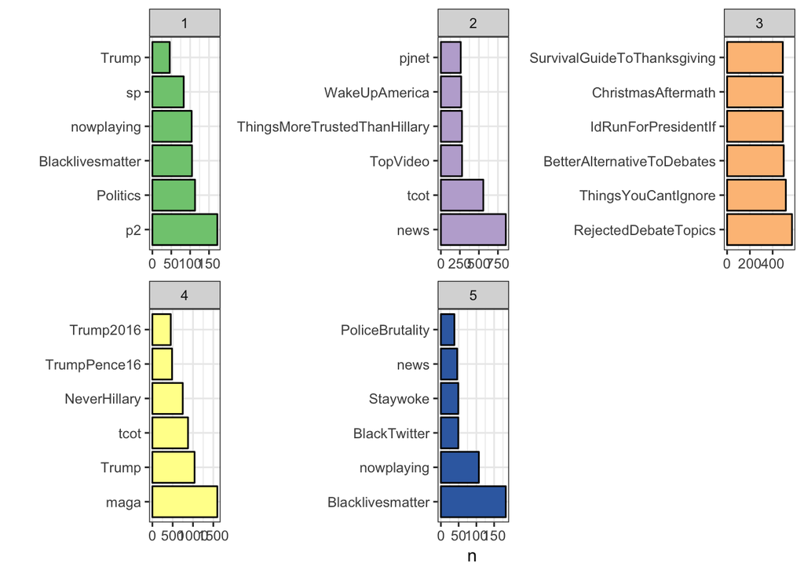

```r
community_hashtags %>%
  dplyr::mutate(hashtags = purrr::map2_chr(hashtags, community, ~paste0(paste0(rep(' ', as.numeric(.y)), collapse = ''), .x))) %>%
  dplyr::arrange(desc(n)) %>%
  dplyr::mutate(hashtags = factor(hashtags, unique(hashtags))) %>%
  ggplot2::ggplot(ggplot2::aes(x = hashtags, y = n, fill = as.character(community))) +
  ggplot2::geom_col(color = 'black') +
  ggplot2::facet_wrap(~community, scales = 'free') +
  ggplot2::scale_fill_manual(values = community_pal) +
  ggplot2::coord_flip()+
  ggplot2::theme_bw() +
  ggplot2::theme(legend.position="none") +
  ggplot2::labs(
    x = ''
  )
```

# Explore the usage of hashtags

## Create a bipartite graph

Let’s revisit the `tweet_hashtag` data frame we created earlier.

```r
head(tweet_hashtag) %>%
  knitr::kable()
```

| user_key | hashtags |
| --- | --- |
| ryanmaxwell_1 | IslamKills |
| queenofthewo | ChristmasAftermath |
| hiimkhloe | Blacklivesmatter |
| jasper_fly | MyFarewellWordsWouldBe |
| giselleevns | My2017BiggestHope |
| pamela_moore13 | Obama |

If the first two columns of a data frame represent the two connected nodes in an edge list, then this data frame represents a bipartite network in which one node type is **user** and the other node type is **hashtag**.

| user_key | hashtags | weight | type |
| --- | --- | --- | --- |
| @newspeakdaily | #politics | 735 | used_hashtag |
| @ameliebaldwin | #maga | 597 | used_hashtag |
| @kansasdailynews | #news | 573 | used_hashtag |
| @onlinecleveland | #politics | 501 | used_hashtag |
| @washingtonline | #politics | 393 | used_hashtag |
| @todaybostonma | #politics | 377 | used_hashtag |

```
## IGRAPH 4093a70 DNWB 13336 36366 --
## + attr: name (v/c), type (v/c), color (v/c), size (v/n), weight
## | (e/n), type (e/c)
```

Again, to minimize the number of edges we got the count of **user_key** -> **hashtags** connection. We only want to keep the edges that “matter” and so we remove connections that occur less than a certain amount of times.

```r
filter_n <- 6

tweet_hashtag_g <- tweet_hashtag_g %>%
  {. - igraph::E(.)[weight < filter_n]} %>%   #remove edges with weight less than the cutoff
  {. - igraph::V(.)[igraph::degree(.) == 0]}  #remove vertices that have no connections

summary(tweet_hashtag_g)
```

```
## IGRAPH 358e62f DNWB 1027 3732 --
## + attr: name (v/c), type (v/c), color (v/c), size (v/n), weight
## | (e/n), type (e/c)
```

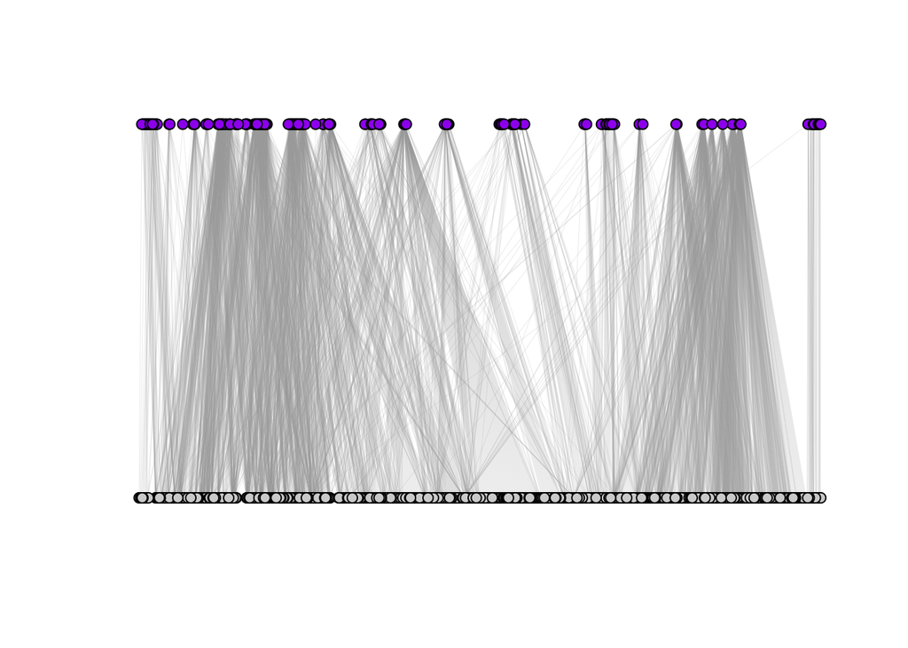

```r
set.seed(4321)
tweet_hashtag_g %>%
  plot(
     vertex.label = '',
     edge.arrow.mode = '-',
     edge.width = .1,
     layout = igraph::layout_as_bipartite(., types = igraph::V(.)$type == 'hashtag'),
     asp = 0
     )
```

The cool thing about bipartite graphs is that we can derive single type graphs. That is, we can project a new graph by combining two nodes of the same type by the mutual neighboring nodes they share.

```r
tweet_hashtag_g %>%
  {
    igraph::V(.)$type <- igraph::V(.)$type == 'user'; #boolean type is necessary for bipartite projection
    igraph::V(.)$degree <- igraph::degree(.); #the total number of connected edges
    igraph::V(.)$weighted_degree <- igraph::strength(.); #the sum of connected edge weights
    .
  } %>%
  igraph::bipartite_projection() %>%
  {
    . <- purrr::map(., function(x){
      igraph::V(x)$component <-igraph::components(x)$membership;
      return(x)
    })
    hashtag_g <<- .$proj1; #projection 1 is type FALSE (hashtags)
    user_g <<- .$proj2; #projection 2 is type TRUE (user)
  }
```

By projecting the bipartite graph we now have two graphs. A graph where users are indirectly connected to other users by the hashtags they both use…

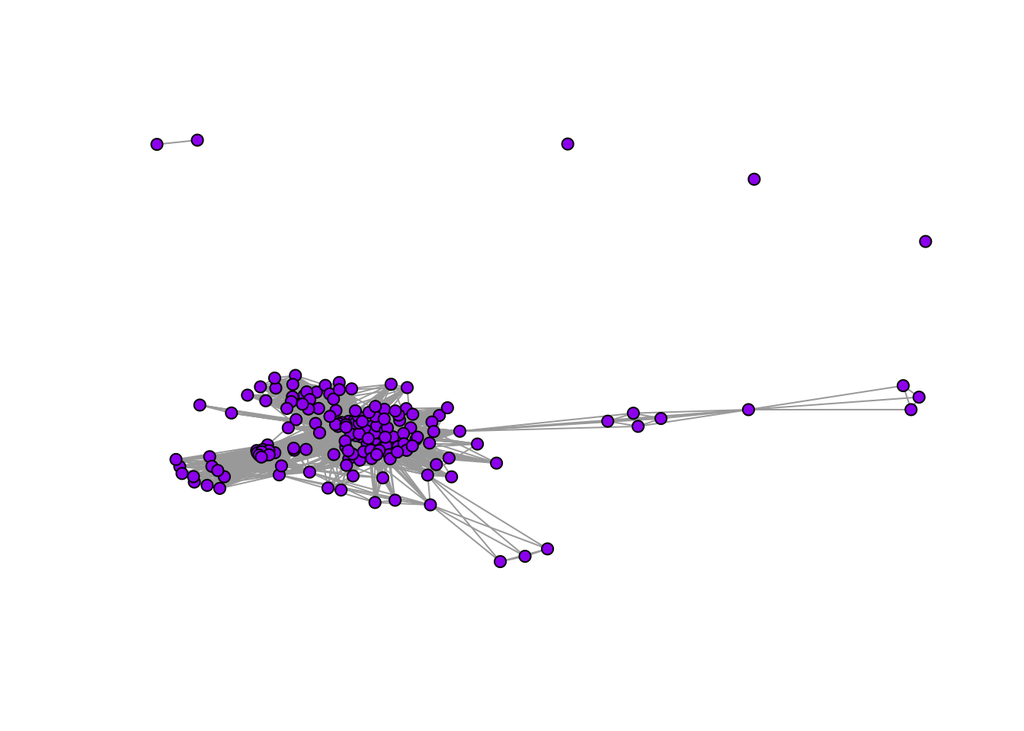

```r
set.seed(4321)
plot(user_g, vertex.size = 3, vertex.label = '', asp = 0)
```

and a graph where hashtags are indirectly connected to other hashtags by the users that use them.

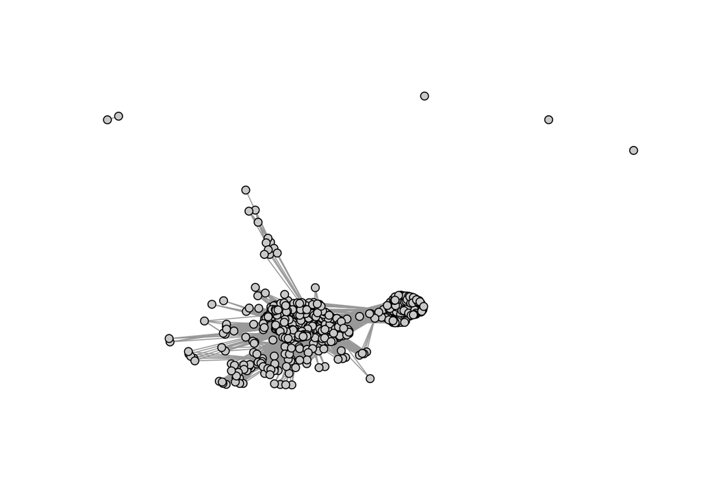

This projected graph of hashtags has multiple components, for now, let’s only exampine the largest component. We can see which vertex belongs to which component with `igraph::components`. We can then group the components together with `igraph::groups` and remove all nodes that do not belong in the largest comonent.

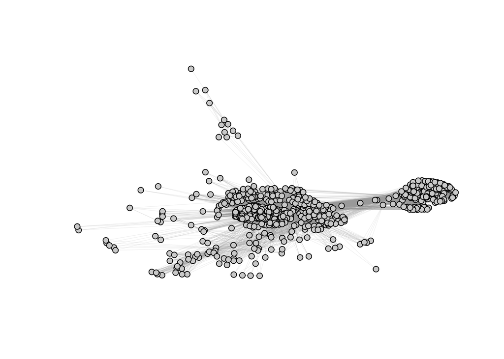

```r
hashtag_g_components <- igraph::components(hashtag_g)

largestComponent <- hashtag_g_components %>%
  igraph::groups() %>%
  {
    maxL <- max(purrr::map_dbl(., length));
    .[purrr::map_lgl(., function(x){length(x) == maxL})] %>%
      unlist()
  } %>%
  {hashtag_g - igraph::V(hashtag_g)[!name %in% .]}


plot(largestComponent, vertex.size = 3, vertex.label = '', edge.width = .1, asp = 0)
```

We can now return to the measurements and community detection alorithms we used earlier.

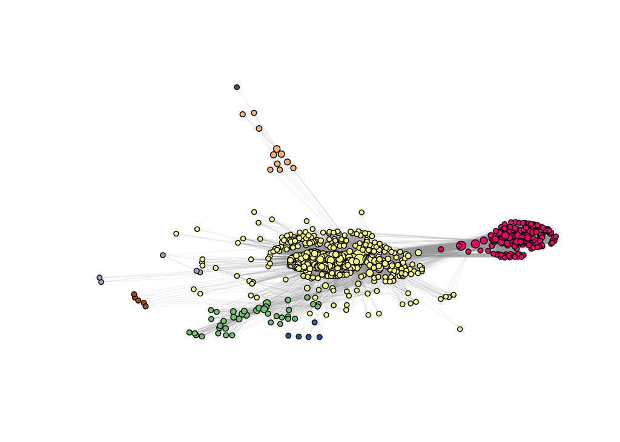

```r
igraph::V(largestComponent)$community <- igraph::walktrap.community(largestComponent)$membership
igraph::V(largestComponent)$PageRank <- igraph::page_rank(largestComponent)$vector

hashtag_pal <- scales::brewer_pal('qual')(max(igraph::V(largestComponent)$community))
names(hashtag_pal) <- as.character(1:length(hashtag_pal)) #named vector is useful for ggplot2

igraph::V(largestComponent)$color <- purrr::map_chr(igraph::V(largestComponent)$community, ~hashtag_pal[.x])

largestComponent %>%
  plot(
    vertex.label= '',
    vertex.size = igraph::V(.)$PageRank/max(igraph::V(.)$PageRank) * 5 + 2,
    edge.width = .1,
    asp = 0
  )
```

Let’s take a look at what hashtags are placed together in the same communities.

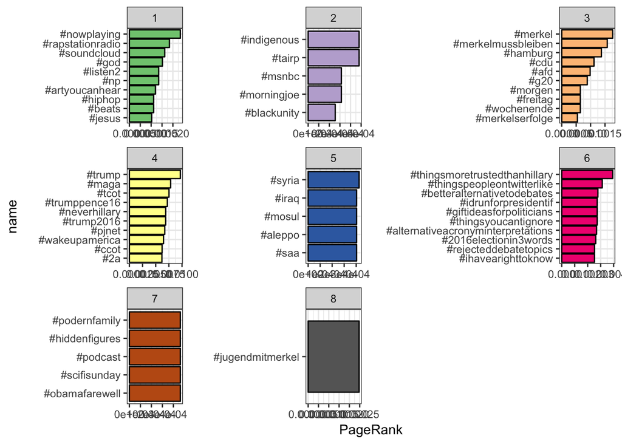

We’ve already identified the different communities, now let’s examine how the different communities interact with eachothe. We can now create super nodes that represent the communities. Edges in this new graph would represent people who used hashtags from two different communities. We can do this by converting the graph back to a data frame and combining the hashtags that belong in the same community togeather.

```r
largestComponent_summary <- largestComponent %>%
  {
    igraph::E(.)$tailCommunity <- igraph::tail_of(., igraph::E(.))$community; #store node information in
    igraph::E(.)$headCommunity <- igraph::head_of(., igraph::E(.))$community; #edges to reference later
    .
  }

igraph::E(largestComponent_summary)[[1:6]]
```

```
## + 6/64921 edges from 2c62bec (vertex names):
##        tail       head tid hid weight tailCommunity headCommunity
## 1 #politics    #health   1 339      5             4             4
## 2 #politics      #news   1   3     19             4             4
## 3 #politics #cleveland   1  23      1             4             4
## 4 #politics    #sports   1 128     12             4             4
## 5 #politics     #money   1 406      3             4             4
## 6 #politics  #business   1 219      8             4             4
```

```r
vertex_df <- igraph::as_data_frame(largestComponent_summary, 'vertices')
edge_df <- igraph::as_data_frame(largestComponent_summary, 'edges')

edge_df <- edge_df %>%
  dplyr::filter(tailCommunity != headCommunity) %>%# we only want edges connecting two different communities
  #1-6 is the same as 6-1, so let's remove dupliates
  dplyr::mutate(
    tail = purrr::map2_dbl(tailCommunity, headCommunity, min) %>% round %>% as.character(),
    head = purrr::map2_dbl(tailCommunity, headCommunity, max) %>% round %>% as.character()
  ) %>%
  dplyr::group_by(tail, head) %>%
  tidyr::nest(.key = 'top_hashes') %>%
  dplyr::mutate(top_hashes = purrr::map(top_hashes, function(x){
    top_hashes <- x %>%
      dplyr::arrange(dplyr::desc(weight)) %>%
      head(3) %>%
      {paste(.$from, .$to, sep = ' | ', collapse = '\n')}

    })) %>%
  tidyr::unnest()

edge_df
```

```
## # A tibble: 8 x 3
##   tail  head  top_hashes
##   <chr> <chr> <chr>
## 1 4     6     "#maga | #thingsmoretrustedthanhillary\n#trump | #thingsmore…
## 2 1     4     "#nowplaying | #blacklivesmatter\n#nowplaying | #staywoke\n#…
## 3 3     4     "#trump | #merkelmussbleiben\n#trump | #merkel\n#trump | #mo…
## 4 2     4     "#nodapl | #indigenous\n#nodapl | #tairp\n#trump | #indigeno…
## 5 4     7     "#debate | #podernfamily\n#debate | #hiddenfigures\n#debate …
## 6 1     7     "#nowplaying | #podernfamily\n#nowplaying | #hiddenfigures\n…
## 7 3     8     #merkel | #jugendmitmerkel
## 8 4     5     "#syria | #us\n#isis | #syria\n#isis | #iraq"
```

```r
vertex_df <- vertex_df %>%
  dplyr::mutate(community = as.character(community)) %>%
  dplyr::group_by(community) %>%
  tidyr::nest() %>%
  dplyr::mutate(top_hashes = purrr::map_chr(data, function(x){
    x %>%
      head %>%
      .$name %>%
      paste(collapse = '\n') %>%
      stringr::str_replace_all('hashtag_', '')
    })) %>%
  dplyr::select(-data) %>%
  dplyr::mutate(color = purrr::map_chr(community, function(x){hashtag_pal[x]}))

vertex_df
```

```
## # A tibble: 8 x 3
##   community top_hashes                                               color
##   <chr>     <chr>                                                    <chr>
## 1 4         "#politics\n#maga\n#news\n#trump\n#neverhillary\n#topvi… #FFFF…
## 2 6         "#makemehateyouinonephrase\n#sometimesitsokto\n#idrunfo… #F002…
## 3 3         "#merkelmussbleiben\n#merkel\n#g20\n#morgen\n#merkelser… #FDC0…
## 4 1         "#nowplaying\n#listen2\n#god\n#soundcloud\n#np\n#tashif… #7FC9…
## 5 7         "#podernfamily\n#hiddenfigures\n#podcast\n#scifisunday\… #BF5B…
## 6 5         "#syria\n#iraq\n#mosul\n#aleppo\n#saa"                   #386C…
## 7 8         #jugendmitmerkel                                         #6666…
## 8 2         "#indigenous\n#tairp\n#blackunity\n#msnbc\n#morningjoe"  #BEAE…
```

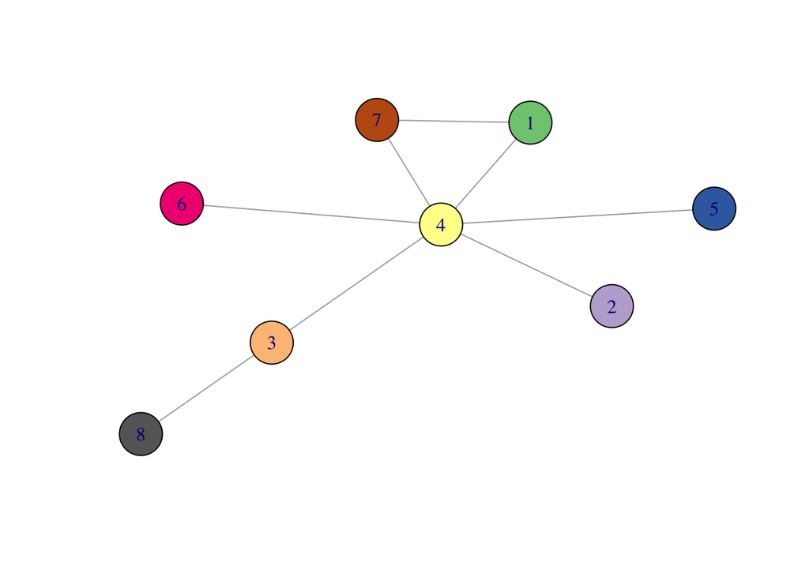

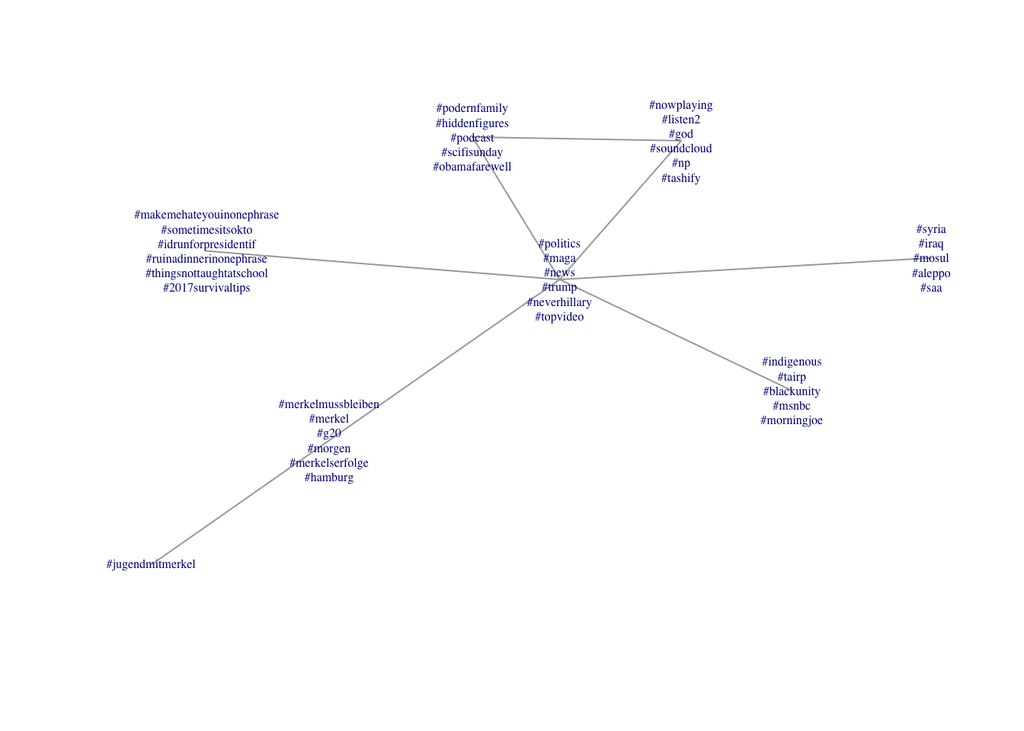

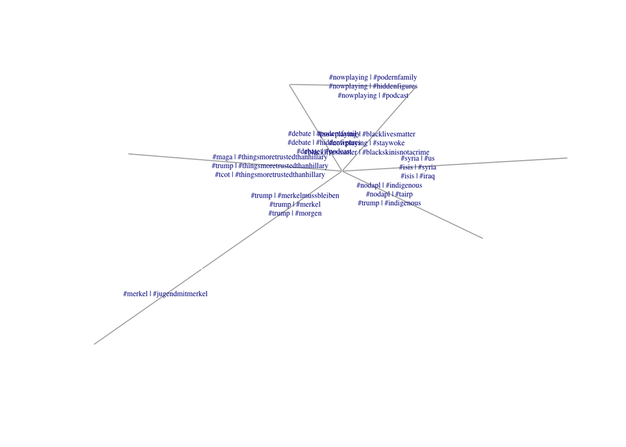

```r
set.seed(4321)
largestComponent_summary <- igraph::graph_from_data_frame(edge_df, F, vertex_df)
 plot(largestComponent_summary, asp = 0)
```